# lab-ch7

Austin Melendez

2026-04-02

Section 7.9: Exercises 8, 9, 11

```r
library(ISLR2)
library(glmnet)
library(pls)
library(leaps)
```

## Exercise 8

Fit some of the non-linear models investigated in this chapter to the `Auto` data set. Is there evidence for non-linear relationships in this data set?

### A

```r
library(ISLR2)
library(splines)

data(Auto)

# Polynomial
fit_poly <- lm(mpg ~ poly(horsepower, 4), data = Auto)

# Regression spline
fit_bs <- lm(mpg ~ bs(horsepower, df = 5), data = Auto)

summary(fit_poly)
```

```
##
## Call:
## lm(formula = mpg ~ poly(horsepower, 4), data = Auto)
##
## Residuals:
##      Min       1Q   Median       3Q      Max
## -14.8820  -2.5802  -0.1682   2.2100  16.1434
##
## Coefficients:
##                       Estimate Std. Error t value Pr(>|t|)
## (Intercept)            23.4459     0.2209 106.161   <2e-16 ***
## poly(horsepower, 4)1 -120.1377     4.3727 -27.475   <2e-16 ***
## poly(horsepower, 4)2   44.0895     4.3727  10.083   <2e-16 ***
## poly(horsepower, 4)3   -3.9488     4.3727  -0.903    0.367
## poly(horsepower, 4)4   -5.1878     4.3727  -1.186    0.236
## ---
## Signif. codes:  0 '***' 0.001 '**' 0.01 '*' 0.05 '.' 0.1 ' ' 1
##
## Residual standard error: 4.373 on 387 degrees of freedom
## Multiple R-squared:  0.6893, Adjusted R-squared:  0.6861
## F-statistic: 214.7 on 4 and 387 DF,  p-value: < 2.2e-16
```

```r
summary(fit_bs)
```

```
##
## Call:
## lm(formula = mpg ~ bs(horsepower, df = 5), data = Auto)
##
## Residuals:
##      Min       1Q   Median       3Q      Max
## -15.7196  -2.6119  -0.2532   2.2002  15.3446
##
## Coefficients:
##                         Estimate Std. Error t value Pr(>|t|)
## (Intercept)               33.024      1.712  19.290  < 2e-16 ***
## bs(horsepower, df = 5)1    5.682      2.611   2.176   0.0301 *
## bs(horsepower, df = 5)2   -8.368      1.740  -4.810 2.17e-06 ***
## bs(horsepower, df = 5)3  -17.284      2.715  -6.366 5.53e-10 ***
## bs(horsepower, df = 5)4  -23.210      2.956  -7.852 4.10e-14 ***
## bs(horsepower, df = 5)5  -18.937      2.694  -7.029 9.49e-12 ***
## ---
## Signif. codes:  0 '***' 0.001 '**' 0.01 '*' 0.05 '.' 0.1 ' ' 1
##
## Residual standard error: 4.29 on 386 degrees of freedom
## Multiple R-squared:  0.7017, Adjusted R-squared:  0.6979
## F-statistic: 181.6 on 5 and 386 DF,  p-value: < 2.2e-16
```

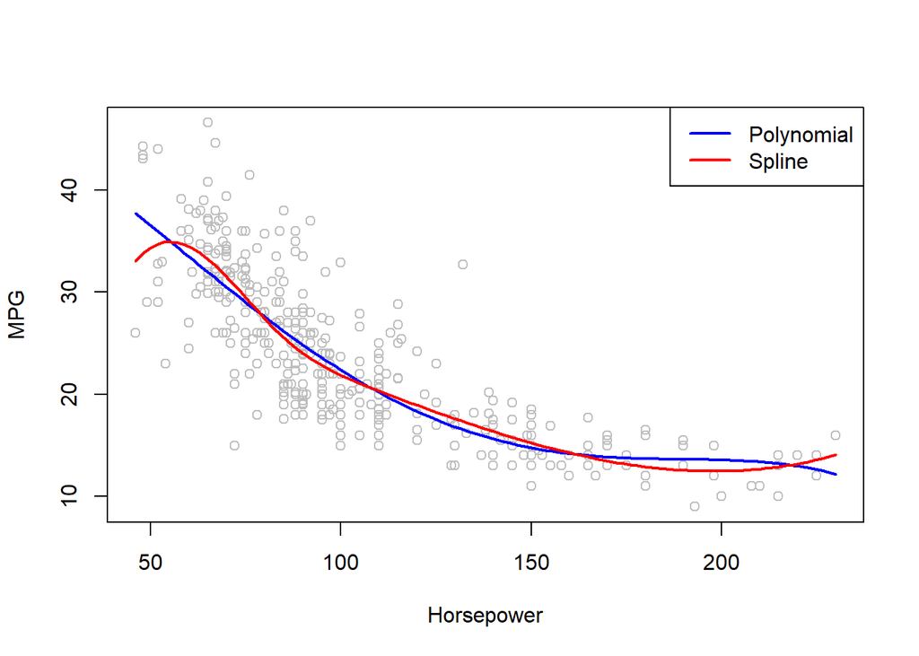

```r
hp_grid <- seq(min(Auto$horsepower), max(Auto$horsepower), length = 100)

pred_poly <- predict(fit_poly, newdata = list(horsepower = hp_grid))
pred_bs <- predict(fit_bs, newdata = list(horsepower = hp_grid))

plot(Auto$horsepower, Auto$mpg, col = "grey",
     xlab = "Horsepower", ylab = "MPG")

lines(hp_grid, pred_poly, col = "blue", lwd = 2)
lines(hp_grid, pred_bs, col = "red", lwd = 2)

legend("topright", legend = c("Polynomial", "Spline"),
       col = c("blue","red"), lwd = 2)
```

- Strong evidence of non-linearity.
- `MPG` declines rapidly at low horsepower, then levels off.
- Splines capture this pattern more smoothly than polynomials.

## Exercise 9

From the `Boston` data, we will treat `dis` as the predictor and `nox` as the response.

### A

Use the poly() function to fit a cubic polynomial regression to predict `nox` using `dis`.

```r
data(Boston)

fit3 <- lm(nox ~ poly(dis, 3), data = Boston)
summary(fit3)
```

```
##
## Call:
## lm(formula = nox ~ poly(dis, 3), data = Boston)
##
## Residuals:
##       Min        1Q    Median        3Q       Max
## -0.121130 -0.040619 -0.009738  0.023385  0.194904
##
## Coefficients:
##                Estimate Std. Error t value Pr(>|t|)
## (Intercept)    0.554695   0.002759 201.021  < 2e-16 ***
## poly(dis, 3)1 -2.003096   0.062071 -32.271  < 2e-16 ***
## poly(dis, 3)2  0.856330   0.062071  13.796  < 2e-16 ***
## poly(dis, 3)3 -0.318049   0.062071  -5.124 4.27e-07 ***
## ---
## Signif. codes:  0 '***' 0.001 '**' 0.01 '*' 0.05 '.' 0.1 ' ' 1
##
## Residual standard error: 0.06207 on 502 degrees of freedom
## Multiple R-squared:  0.7148, Adjusted R-squared:  0.7131
## F-statistic: 419.3 on 3 and 502 DF,  p-value: < 2.2e-16
```

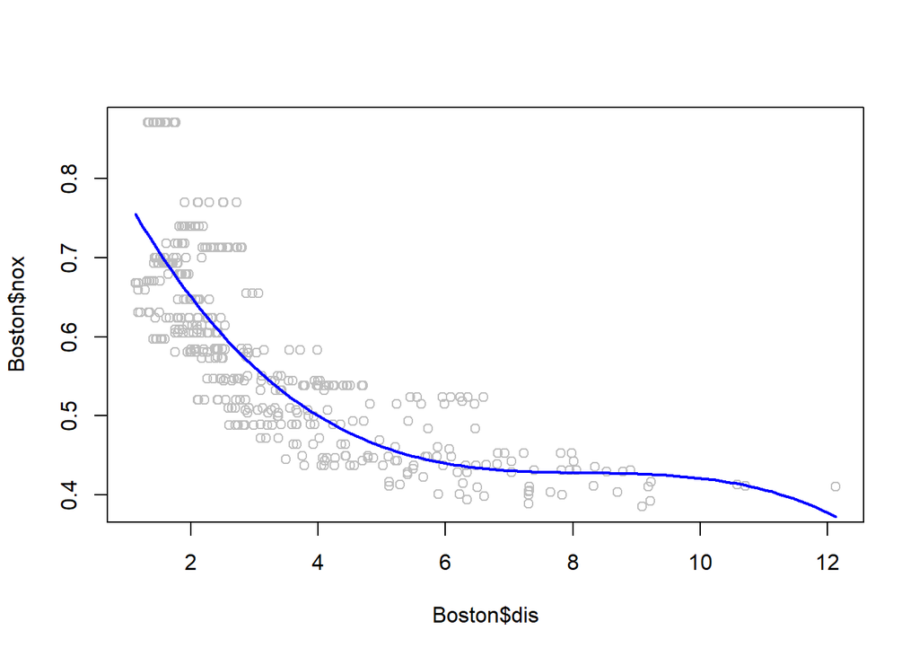

```r
dis_grid <- seq(min(Boston$dis), max(Boston$dis), length = 100)
pred3 <- predict(fit3, newdata = list(dis = dis_grid))

plot(Boston$dis, Boston$nox, col = "grey")
lines(dis_grid, pred3, col = "blue", lwd = 2)
```

### B

Plot the polynomial fits for a range of different polynomial degrees (from 1 to 10).

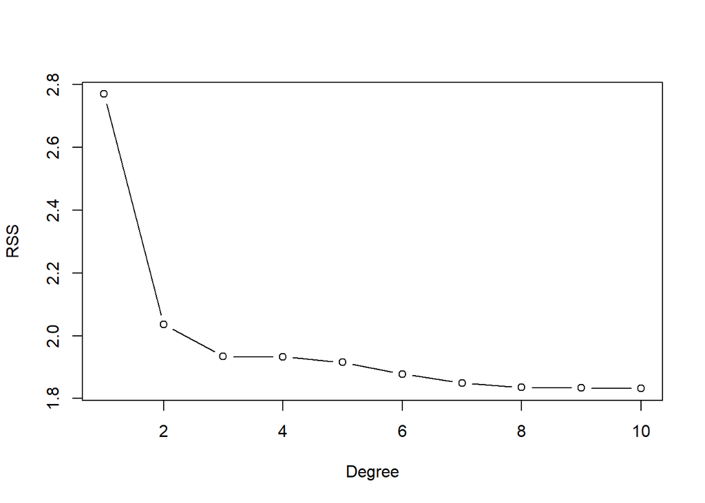

```r
rss <- rep(NA, 10)

for (i in 1:10) {
  fit <- lm(nox ~ poly(dis, i), data = Boston)
  rss[i] <- sum(residuals(fit)^2)
}

plot(1:10, rss, type = "b", xlab = "Degree", ylab = "RSS")
```

```r
print(mean(rss))
```

```
## [1] 1.981508
```

### C

Perform cross-validation or another approach to select the optimal degree for the polynomial.

```r
library(boot)
```

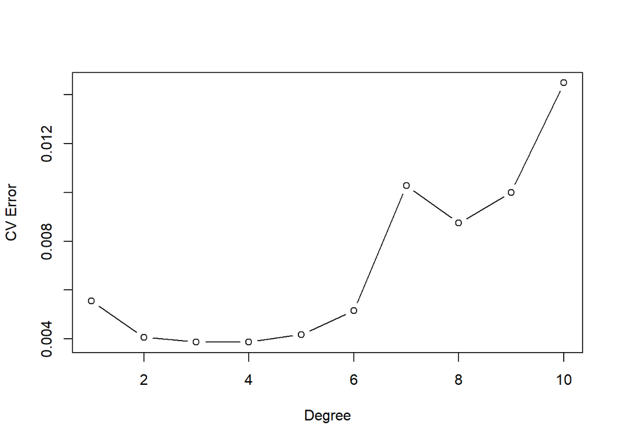

```r
cv_error <- rep(NA, 10)

for (i in 1:10) {
  fit <- glm(nox ~ poly(dis, i), data = Boston)
  cv_error[i] <- cv.glm(Boston, fit, K = 10)$delta[1]
}

plot(1:10, cv_error, type = "b",
     xlab = "Degree", ylab = "CV Error")
```

I would select degree 3 or 4 since it has the lowest CV error rate.

### D

Use the bs() function to fit a regression spline to predict `nox` using `dis`. Report the output for the fit using four degrees of freedom.

```r
fit_bs <- lm(nox ~ bs(dis, df = 4), data = Boston)
summary(fit_bs)
```

```
##
## Call:
## lm(formula = nox ~ bs(dis, df = 4), data = Boston)
##
## Residuals:
##       Min        1Q    Median        3Q       Max
## -0.124622 -0.039259 -0.008514  0.020850  0.193891
##
## Coefficients:
##                  Estimate Std. Error t value Pr(>|t|)
## (Intercept)       0.73447    0.01460  50.306  < 2e-16 ***
## bs(dis, df = 4)1 -0.05810    0.02186  -2.658  0.00812 **
## bs(dis, df = 4)2 -0.46356    0.02366 -19.596  < 2e-16 ***
## bs(dis, df = 4)3 -0.19979    0.04311  -4.634 4.58e-06 ***
## bs(dis, df = 4)4 -0.38881    0.04551  -8.544  < 2e-16 ***
## ---
## Signif. codes:  0 '***' 0.001 '**' 0.01 '*' 0.05 '.' 0.1 ' ' 1
##
## Residual standard error: 0.06195 on 501 degrees of freedom
## Multiple R-squared:  0.7164, Adjusted R-squared:  0.7142
## F-statistic: 316.5 on 4 and 501 DF,  p-value: < 2.2e-16
```

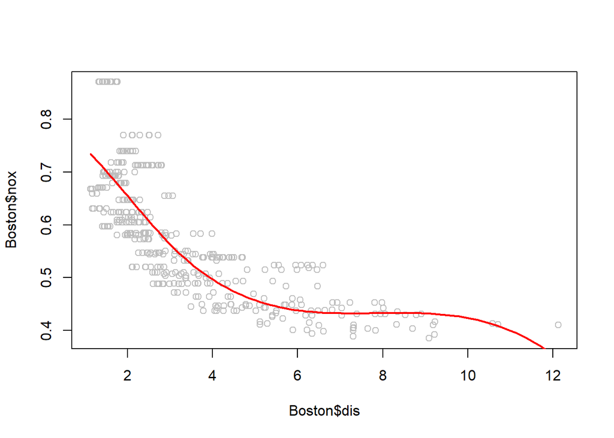

```r
pred_bs <- predict(fit_bs, newdata = list(dis = dis_grid))

plot(Boston$dis, Boston$nox, col = "grey")
lines(dis_grid, pred_bs, col = "red", lwd = 2)
```

### E

Now fit a regression spline for a range of degrees of freedom, and plot the resulting fits and report the resulting RSS.

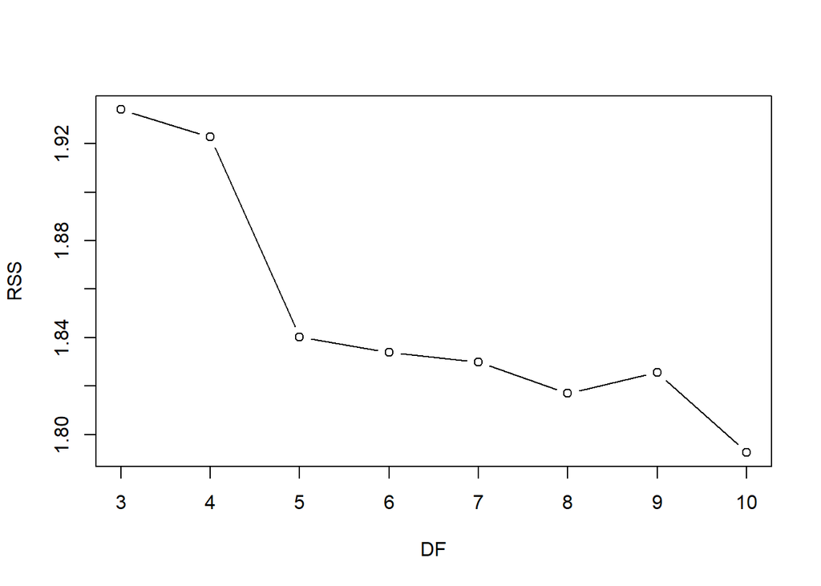

```r
rss_spline <- rep(NA, 10)

for (i in 3:10) {
  fit <- lm(nox ~ bs(dis, df = i), data = Boston)
  rss_spline[i] <- sum(residuals(fit)^2)
}

plot(3:10, rss_spline[3:10], type = "b",
     xlab = "DF", ylab = "RSS")
```

RSS is lowest when degrees of freedom is equal to 10. More generally, RSS decreases with df.

### F

Perform cross-validation or another approach in order to select the best degrees of freedom for a regression spline on this data.

```r
cv_spline <- rep(NA, 10)

for (i in 3:10) {
  fit <- glm(nox ~ bs(dis, df = i), data = Boston)
  cv_spline[i] <- cv.glm(Boston, fit, K = 10)$delta[1]
}
```

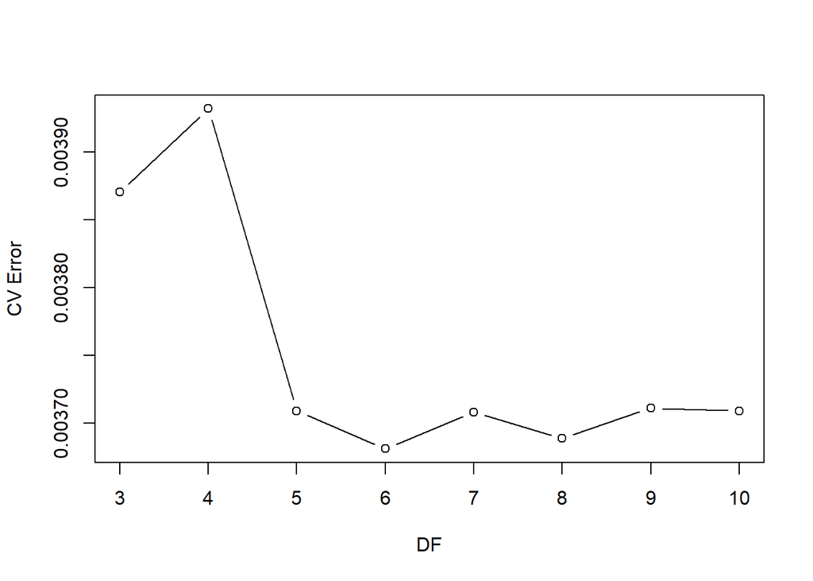

```r
plot(3:10, cv_spline[3:10], type = "b",
     xlab = "DF", ylab = "CV Error")
```

## Exercise 11

In Section 7.7, it was mentioned that GAMs are generally fit using a backfitting approach. We will now explore backfitting in the context of multiple linear regression.

### A

Generate a response $Y$ and two predictors $X_1$ and $X_2$, with $n = 100$.

```r
set.seed(1)
n <- 100

x1 <- rnorm(n)
x2 <- rnorm(n)
y <- 3 + 2*x1 + 4*x2 + rnorm(n)
```

### B-E

Backfitting loop.

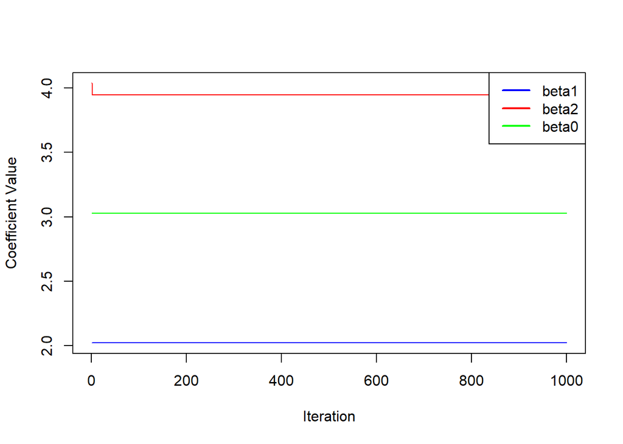

```r
beta1 <- 100
beta2 <- -100

beta0_vals <- beta1_vals <- beta2_vals <- rep(NA, 1000)

for (i in 1:1000) {

  # update beta2
  a <- y - beta1 * x1
  beta2 <- lm(a ~ x2)$coef[2]

  # update beta1
  a <- y - beta2 * x2
  beta1 <- lm(a ~ x1)$coef[2]

  # update beta0
  beta0 <- mean(y - beta1*x1 - beta2*x2)

  beta0_vals[i] <- beta0
  beta1_vals[i] <- beta1
  beta2_vals[i] <- beta2
}

plot(beta1_vals, type = "l", col = "blue",
     ylim = range(c(beta0_vals, beta1_vals, beta2_vals)),
     ylab = "Coefficient Value",
     xlab = "Iteration")
lines(beta2_vals, col = "red")
lines(beta0_vals, col = "green")

legend("topright", legend = c("beta1","beta2","beta0"),
       col = c("blue","red","green"), lwd = 2)
```

This plot looks wrong… unless the coefficient values are being converged too very rapidly?

### F

Compare your answer in (e) to the results of simply performing multiple linear regression to predict $Y$ using $X_1$ and $X_2$.

```r
fit <- lm(y ~ x1 + x2)
```

### G

On this data set, how many backfitting iterations were required in order to obtain a “good” approximation to the multiple regression coefficient estimates?